# Week 7: Visualization and Dashboards

Ted Laderas

2018-08-06

This week we will try to understand the kinds of readmissions that are in our dataset. We’re going to start with the analytic table we built in Assignment 5 and use some tools within R to do this. Before we get started, we need to install the `tidyverse` set of packages in R. The `tidyverse` is a set of R packages that help you visualize and data munge the data. If you haven’t already installed the `tidyverse`, go ahead and do so:

```
install.packages("tidyverse")
```

## Loading the data in

I’m providing you with a version of the `analytic` table we calculated in weeks 5/6 so we can do some visualization as `analytic.csv`. We’ll take our analytic table and load it as a `data.frame` in R using the `readr` package.

```r
library(tidyverse)
analytic_table <- readr::read_csv("analytic.csv")

head(analytic_table)
```

```
## # A tibble: 6 x 9
##   patientid Event_ID encounter_type outcome      Admit_date Discharge_date
##       <int>    <int>          <int> <chr>        <date>     <date>
## 1         1      108             22 SNF          2014-01-01 2014-01-08
## 2         1      109             22 SNF          2014-01-13 2014-01-20
## 3         2     1333             22 Discharged ~ 2014-01-01 2014-01-13
## 4         3       71             22 SNF          2014-01-01 2014-01-07
## 5         4      886             22 Discharged ~ 2014-01-01 2014-01-07
## 6         5       73             22 Discharged ~ 2014-01-01 2014-01-08
## # ... with 3 more variables: Admit_source <chr>, indexadmit <int>,
## #   Readmit30 <int>
```

Some things to notice: `readr::read_delim()` is smart enough to recognize dates from the formatting, and makes `Admit_date` and `Discharge_date` into the `<date>` format. However, there’s a few columns in the table that we want to change the format of so they will be easier to work with. We’re going to change the type of `encounter_type`, `outcome`, `Admit_source`, `indexadmit` and `Readmit30` variables to be `factor`, which is R’s version of categorical variables. This will help us a lot when we are visualizing and filtering the data.

We can do this by providing an argument to `col_types` about the data types we want to specify for each category. We do this by using the `cols()` function and specifying a named argument for each columns. For each column, we want to specify the value of, we need to name it and specify using a `col_` function what datatype we want to specify it as. There’s five that are really useful to us:

- `col_logical()` (for TRUE/FALSE variables)
- `col_integer()` (for count variables)
- `col_character()` (for strings)
- `col_double()` (for decimals)
- `col_factor()` (for factors)

Here we’re using `col_factor()` to specify the following columns to be factors. We need to specify a `NULL` argument so it will guess the categories (which are called *levels*) for our variables. Otherwise, we’d have to specify every level for every variable.

```r
analytic_table <- readr::read_csv("analytic.csv",
                                    col_types = cols(
                                      encounter_type = col_factor(NULL),
                                      outcome = col_factor(NULL),
                                      Admit_source= col_factor(NULL),
                                      indexadmit = col_factor(NULL),
                                      Readmit30 = col_factor(NULL)
                                    ))

head(analytic_table)
```

```
## # A tibble: 6 x 9
##   patientid Event_ID encounter_type outcome      Admit_date Discharge_date
##       <int>    <int> <fct>          <fct>        <date>     <date>
## 1         1      108 22             SNF          2014-01-01 2014-01-08
## 2         1      109 22             SNF          2014-01-13 2014-01-20
## 3         2     1333 22             Discharged ~ 2014-01-01 2014-01-13
## 4         3       71 22             SNF          2014-01-01 2014-01-07
## 5         4      886 22             Discharged ~ 2014-01-01 2014-01-07
## 6         5       73 22             Discharged ~ 2014-01-01 2014-01-08
## # ... with 3 more variables: Admit_source <fct>, indexadmit <fct>,
## #   Readmit30 <fct>
```

## Calculating length of stay

Here I’m calculating the `length_of_stay` using the `mutate()` function, which lets me calculate a new variable based on the other variables. If we `glimpse()` our new table, we can see we have a new variable called `length_of_stay`. What format is it in?

```r
analytic_table <- analytic_table %>% mutate(length_of_stay = Discharge_date - Admit_date)
```

## An overview of the data

I’m going to use a package called `skimr` to summarize the data - make sure you `install.packages("skimr")`:

```r
library(skimr)
skimr::skim(analytic_table)
```

```
## Skim summary statistics
##  n obs: 39634
##  n variables: 10
##
## -- Variable type:Date -----------------------------------------------------
##        variable missing complete     n        min        max     median
##      Admit_date       0    39634 39634 2014-01-01 2014-04-22 2014-01-01
##  Discharge_date       0    39634 39634 2014-01-02 2014-04-29 2014-01-06
##  n_unique
##       109
##       114
##
## -- Variable type:difftime -------------------------------------------------
##        variable missing complete     n    min      max median n_unique
##  length_of_stay       0    39634 39634 0 days 113 days 5 days       83
##
## -- Variable type:factor ---------------------------------------------------
##        variable missing complete     n n_unique
##    Admit_source       0    39634 39634        4
##  encounter_type       0    39634 39634        1
##      indexadmit       0    39634 39634        2
##         outcome       0    39634 39634        3
##       Readmit30       0    39634 39634        2
##                                   top_counts ordered
##  Eme: 18801, Tra: 9962, Cli: 9105, SNF: 1766   FALSE
##                             22: 39634, NA: 0   FALSE
##                     1: 34509, 0: 5125, NA: 0   FALSE
##     Dis: 19757, SNF: 15900, Reh: 3977, NA: 0   FALSE
##                     0: 34488, 1: 5146, NA: 0   FALSE
##
## -- Variable type:integer --------------------------------------------------
##   variable missing complete     n     mean       sd p0     p25     p50
##   Event_ID       0    39634 39634 19851.57 11460.6   1 9927.25 19855.5
##  patientid       0    39634 39634 17261.57  9989.19  1 8586.25 17259.5
##       p75  p100     hist
##  29773.75 39701 ▇▇▇▇▇▇▇▇
##  25928    34532 ▇▇▇▇▇▇▇▇
```

Let’s take a look at the summary table. How many observations are in the table? How many variables?

Now we see everything is nicely formatted and ready to be visualized.

## Another way to look at the data: `glimpse`

The `glimpse` function, from the `dplyr` package, is another useful tool to look at a `data.frame`:

```r
glimpse(analytic_table)
```

```
## Observations: 39,634
## Variables: 10
## $ patientid      <int> 1, 1, 2, 3, 4, 5, 5, 6, 6, 7, 8, 9, 10, 11, 12,...
## $ Event_ID       <int> 108, 109, 1333, 71, 886, 73, 74, 98, 99, 893, 2...
## $ encounter_type <fct> 22, 22, 22, 22, 22, 22, 22, 22, 22, 22, 22, 22,...
## $ outcome        <fct> SNF, SNF, Discharged Home, SNF, Discharged Home...
## $ Admit_date     <date> 2014-01-01, 2014-01-13, 2014-01-01, 2014-01-01...
## $ Discharge_date <date> 2014-01-08, 2014-01-20, 2014-01-13, 2014-01-07...
## $ Admit_source   <fct> Emergency Room, Transfer, Clinic, Transfer, Eme...
## $ indexadmit     <fct> 1, 0, 1, 1, 1, 1, 0, 1, 0, 1, 1, 1, 1, 1, 1, 1,...
## $ Readmit30      <fct> 1, 0, 0, 0, 0, 1, 0, 1, 0, 0, 0, 0, 0, 0, 0, 0,...
## $ length_of_stay <time> 7 days, 7 days, 12 days, 6 days, 6 days, 7 day...
```

## What is a statistical graphic?

Ok, now that we’re happy with our `analytic_table` we can finally get to visualize it!

What is a statistical graphic? Well, to quote Chester Ismay, a statistical graphic consists of the following:

### A `mapping` of `data` variables

### to `aes()`thetic attributes

### of `geom_`etric objects.

We’ll go over this in detail with an example below.

## Your first `ggplot`

We’re just going to summarize `analytic_table` in terms of a couple variables first. The first thing we’ll generate is a bar plot of the `Readmit30` variables.

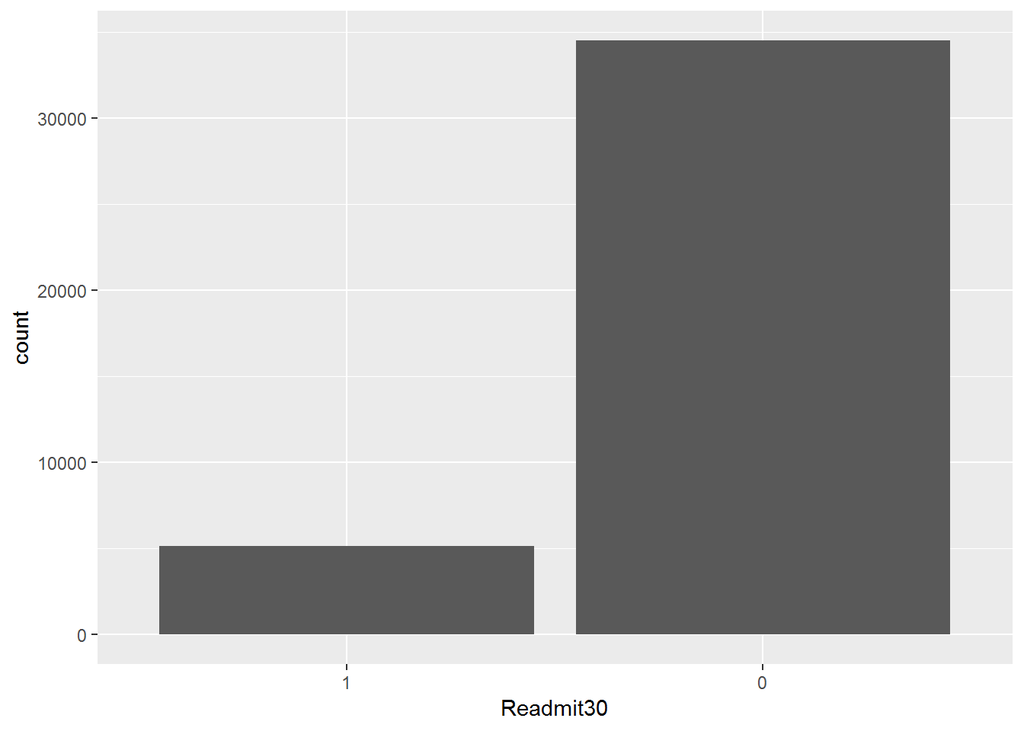

```r
 bar_plot1 <-  ggplot(data=analytic_table,
                      mapping=aes(x=Readmit30)) +
               geom_bar()

 bar_plot1
```

Let’s talk about the `data` and `mapping` arguments first. The `data` argument is our `data.frame()` of interest: `analytic_table`. Things get a little more interesting with the `mapping` argument. Let’s take it apart:

```
aes(x=Readmit30)
```

The `geom_bar()` is the actual *geometric layout* that we are going to display the data on. If you look at the documentation for `geom_bar()` (`?geom_bar`) you can see that the geometic layout contains the following aesthetics that can be mapped:

- x
- y
- alpha
- colour
- fill
- group
- linetype
- size

Only the `x` variable is required for `geom_bar`. Here’s a list of all of the geoms: https://ggplot2.tidyverse.org/reference/#section-layer-geoms

The other thing to notice is that we chain the `ggplot()` and `geom_bar()` statements with a `+` sign. The strength of `ggplot2` is the fact that you can layer multiple datasets and multiple types of visualizations as layers on the ggplot.

## Getting more complicated: adding a `fill` aesthetic

We can get more complicated with mapping a variable to the fill aesthetic:

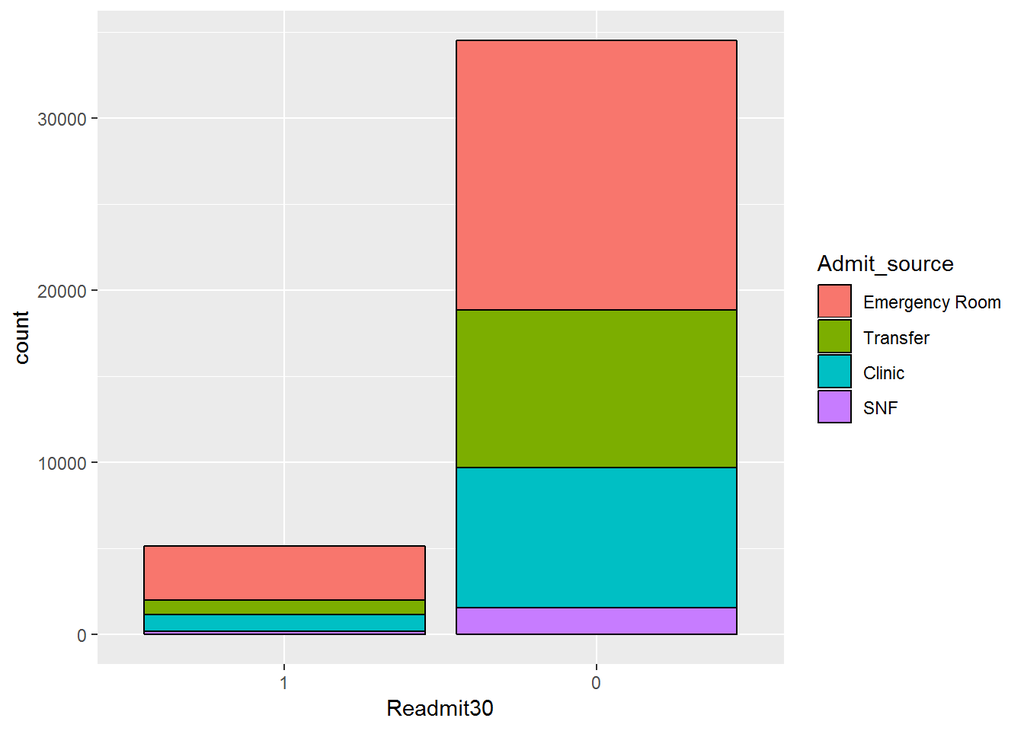

```r
 bar_plot1 <-  ggplot(data=analytic_table,
                      mapping=aes(x=Readmit30, fill=Admit_source)) +
               geom_bar(color="black")

 bar_plot1
```

Try removing the `color="black"` argument. What happens to the plot?

## Proportional Plots

We may just want to understand whether the proportion of emergency room admits is different for our readmission cases compared to the other cases. In this case, we can use a stacked proportional barplot:

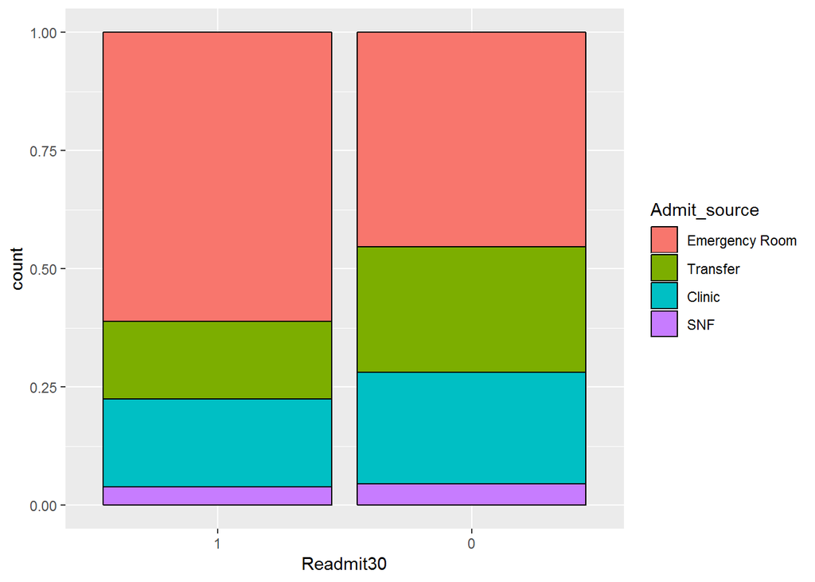

```r
 bar_plot1 <-  ggplot(data=analytic_table,
                      mapping=aes(x=Readmit30, fill=Admit_source)) +
               geom_bar(color="black", position="fill")

 bar_plot1
```

## Dodged bars

If you prefer a dodged plot, you can specify `position="dodge"`:

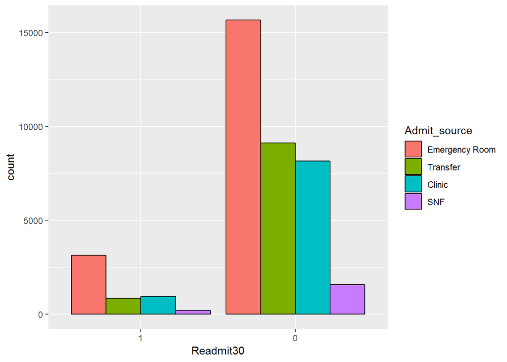

```r
 bar_plot1 <-  ggplot(data=analytic_table,
                      mapping=aes(x=Readmit30, fill=Admit_source)) +
               geom_bar(color="black", position="dodge")

 bar_plot1
```

## Adding a title

Take a look at the documentation for `ggtitle()` (`?ggtitle`). How do you add a title to a graph?

## Working with Time

We can manipulate dates using the `lubridate` package. Here I’m using the `month()` function to only use the month on our x-axis.

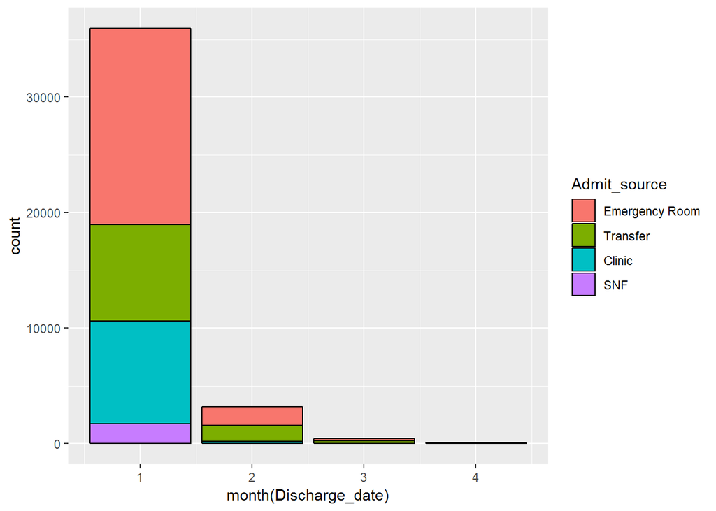

```r
ggplot(data=analytic_table, mapping = aes(x=month(Discharge_date), fill=Admit_source)) + geom_bar(color="black")
```

## Showing a histogram of length of stay

Since `length_of_stay` is a numeric variable, we can plot it as a histogram:

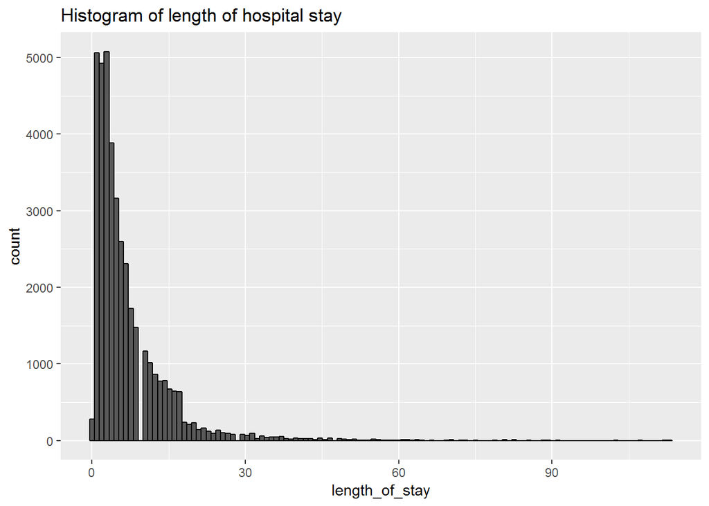

```r
hist_stay <- ggplot(data=analytic_table, mapping = aes(x=length_of_stay)) + geom_histogram(bins = 120, color="black") +
  ggtitle("Histogram of length of hospital stay")

hist_stay
```

## Installing the `patchwork` package

Patchwork is an experimental package that is meant for laying out multiple graphs on the same page. We’ll use it to simulate some dashboards in our data. It isn’t on CRAN yet, so we’ll install it from the GitHub repo.

To install `patchwork`, you’ll first need to install the `devtools` package:

```
install.packages(devtools)
```

Now with `devtools` installed, we can install `patchwork` (please note that ggplot2 needs to be updated to version 3.x):

```
devtools::install_github("thomasp85/patchwork")
```

## Putting Plots together: `patchwork`

Now we can start grouping our plots together. `patchwork` is good about scaling plots with common units to be on the same scale as the others.

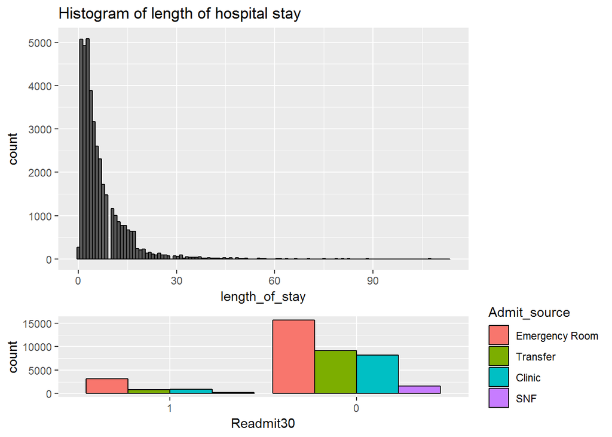

```r
library(patchwork)

combined_graph <- hist_stay + bar_plot1 +
  #specify the plot layout - 1 column, and with
  #height of hist_stay to be 3 times larger than bar_plot1
  plot_layout(ncol=1, heights = c(3,1))

combined_graph
```

You can learn more about arranging plots using `patchwork` on the `patchwork` readme: https://github.com/thomasp85/patchwork/blob/master/README.md